# ZebraFinches

Theresa Michalke

6/11/2021

# 1 Introduction

Our data is a collection of agonistic interactions and locations of individual finches in a grid of 5x5. Measurements were collected in multiple sessions. Each pair of finches nested in the following locations.

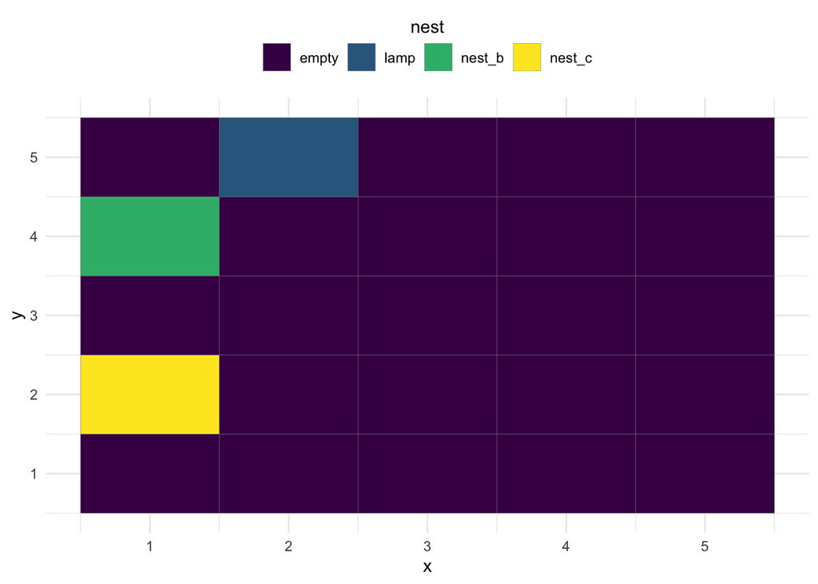

Our analysis consists first on creating and cleaning the data, followed by some visualizations and statistical tests.

## 1.1 Reading Data

```r
my_pile_of_stuff<-read.csv("Birdies_exp.csv") #("Zebra_finch_exp.csv")
my_pile_of_stuff<-as.data.frame(my_pile_of_stuff)
#my_pile_of_stuff
```

This data needs to be formatted in the following ways:

- Data needs to be separated between interactions and movement measurements
- The variable territory denotes the location in a grid with a letter and a number. This needs to be split up and put in an X-Y numeric coordinate system.
- The location of each birds nest is known, but wasnt added to the data. This is important because in the agonistic interactions, the *treatment* is where the food was places, and this corresponds to a nest location
- During the agonistic interactions, we consider a treatment where the food was place, which overlapped with a pair of birds nest location, due to where the birds decided to nest, 2 nests were in close proximity, meaning that depending on the condition we relabelled treatment by proximity to the nest.
- We also want to calculate the distance between an interaction and the proximity to the food

```r
#We obtain the names of the birds, and then map these values to their corresponding nest
birdies<-levels(factor(my_pile_of_stuff$identity))
nests<-c("nest_b","nest_b","lamp","nest_c","nest_c","lamp")
my_pile_of_stuff$nest<-factor(plyr::mapvalues(my_pile_of_stuff$identity,birdies,nests))
my_pile_of_stuff$exp_id<-paste0(my_pile_of_stuff$day,"-",my_pile_of_stuff$session)

#Depending on the treatment, the food location was either close or far from each nest, so we create a new variable to show this
my_pile_of_stuff['closeness']<-"far"
my_pile_of_stuff[my_pile_of_stuff$treatment == my_pile_of_stuff$nest,"closeness"]<-"close"
my_pile_of_stuff[my_pile_of_stuff$treatment=="lamp" & my_pile_of_stuff$nest=="nest_b","closeness"]<-"close"
my_pile_of_stuff[my_pile_of_stuff$treatment =="nest_b" & my_pile_of_stuff$nest=="lamp","closeness"]<-"close"
```

This part takes care of the movement table, as well as making plots with the variable of interest

```r
#We select only rows where territory is measured (this is the measurements of where the finch was in a given time)
movement<-my_pile_of_stuff[!is.na(my_pile_of_stuff$territory),]
movement<-movement[,c(-10,-11)]
tmp<-str_split_fixed(movement$territory, "",n=2)
movement$x_pos<-tmp[,1]
#The way that data was captured, some fields are empty and we convert them to NA
movement$x_pos[movement$x_pos==""]<-NA
#converts the number part into a factor
movement$x_pos<-as.factor(movement$x_pos)
movement$x_pos<-droplevels(movement$x_pos)
movement$x_pos<-as.numeric(movement$x_pos)
#makes the leters into a factor, and converts them to a numeric variable
movement$y_pos<-as.factor(tmp[,2])
movement$y_pos[movement$y_pos==""]<-NA
movement$y_pos<-as.factor(movement$y_pos)
movement$y_pos<-droplevels(movement$y_pos)
movement$y_pos<-as.numeric(movement$y_pos)
#Our setup started numbering the grid from top to bottom, we transform the numbers so visualizations match the experimental set up
#Only taking into account the rows with a territory
movement$y_pos<-movement$y_pos *-1+6
range<-movement[complete.cases(movement$territory),]

#We create a function that takes as an input a variable, and creates a heatmap of the counts of the position of each bird across the grid #normalized by the total amount of recorded events
plot_heat<-function(df,cond){
  #print(cond)
  hm<-df %>% dplyr::count(identity, x_pos,y_pos,df[cond], sort = TRUE)
  #print(hm)
  nd<-df %>% dplyr::count(identity,df[cond], sort = TRUE)
  for(x in 1:dim(nd)[1]){
    hm[hm$identity==nd[x,"identity"] & hm[cond]==nd[x,cond],"n"] <- hm[hm$identity==nd[x,"identity"] & hm[cond]==nd[x,cond],"n"]/nd[x,"n"]
  }
  p<-ggplot(hm,aes(x=x_pos,y=y_pos,fill=n))+geom_tile()+facet_grid(as.formula(paste(cond,"~", "identity")))+scale_fill_viridis(discrete=FALSE) + theme_bw()+theme(plot.title.position = 'plot')+theme(legend.position = 'top')+guides(fill = guide_colorbar(title="Position counts",title.position = 'top', title.hjust = .5,
 barwidth = unit(20, 'lines'), barheight = unit(.5, 'lines'))) +
    labs(title = paste0("Movement per ",cond), xlab= "x position",ylab= "y position")
  print(p)
  return(hm)
}
```

We first visualize the positions of the finches depending on the day

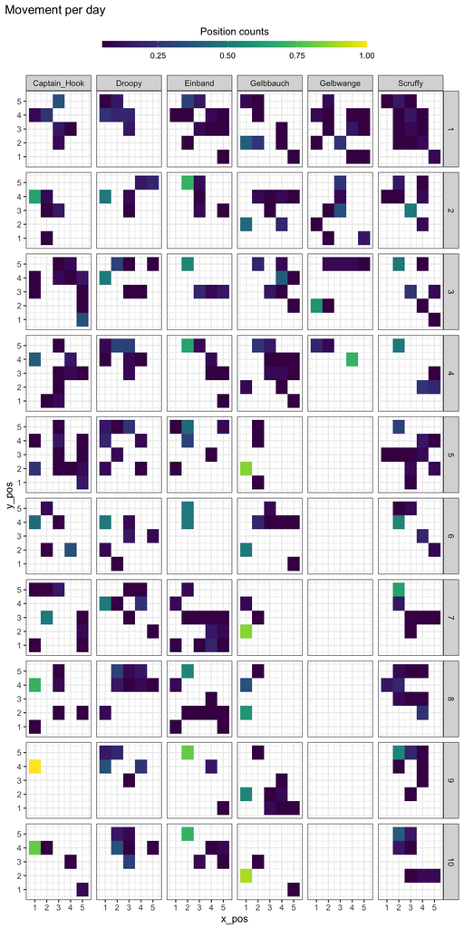

```r
tmp3<-plot_heat(range,"day") #enter whatever variable
```

We also look at the positions dependent on other variables

- cycle
- weather

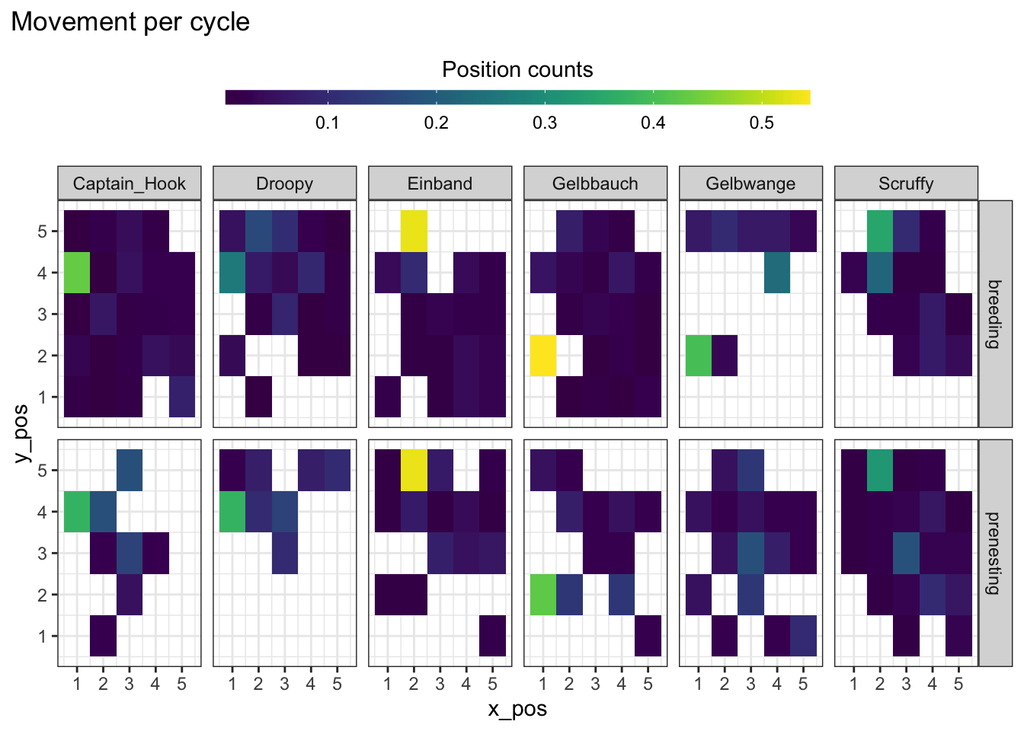

```r
tmp4<-plot_heat(range,"cycle")
```

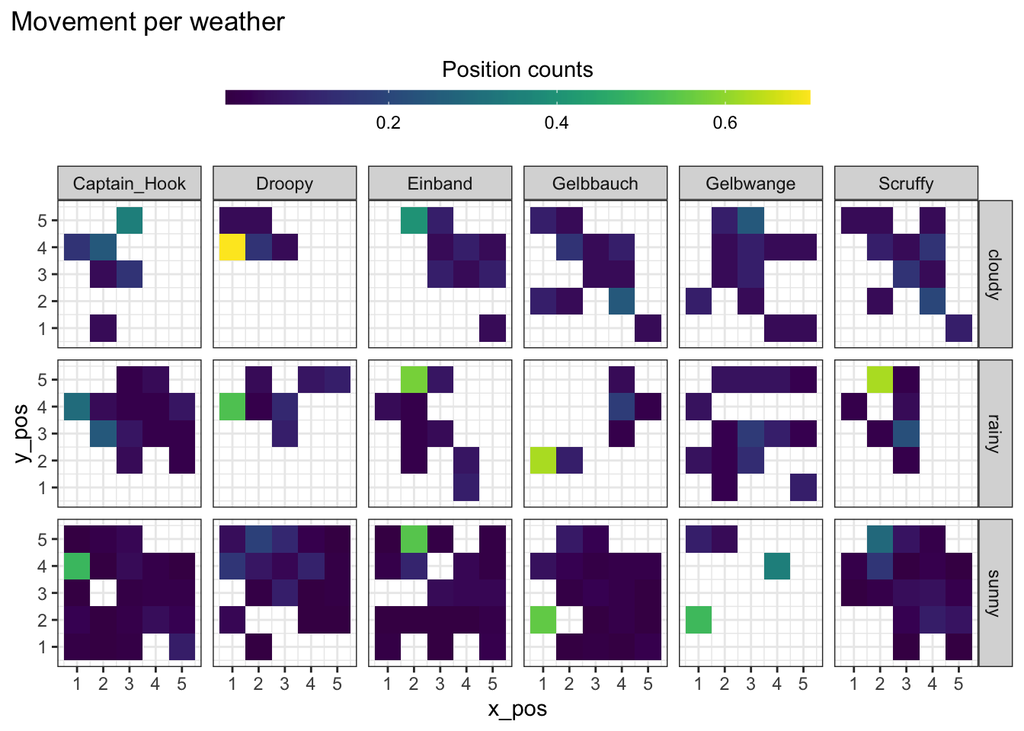

```r
tmp5<-plot_heat(range,"weather")
```

```r
#dev.off()
#for(x in 1:dim(tmp2)[1]){
#  print(x)
#}
```

This part takes care of the interaction table, as well as calculating the distances

```r
interaction<-my_pile_of_stuff[,-9]
interaction$treatment<-as.factor(interaction$treatment)

interaction<-interaction[complete.cases(interaction$agonistic),]

tmp<-str_split_fixed(interaction$agonistic, "",n=2)
interaction$x_pos<-tmp[,1]
#The way that data was captured, some fields are empty and we convert them to NA
interaction$x_pos[interaction$x_pos==""]<-NA

#converts the number part into a factor
interaction$x_pos<-as.factor(interaction$x_pos)
interaction$x_pos<-droplevels(interaction$x_pos)
interaction$x_pos<-as.numeric(interaction$x_pos)

#makes the leters into a factor, and converts them to a numeric variable
interaction$y_pos<-as.factor(tmp[,2])
interaction$y_pos[interaction$y_pos==""]<-NA
interaction$y_pos<-as.factor(interaction$y_pos)
interaction$y_pos<-droplevels(interaction$y_pos)
interaction$y_pos<-as.numeric(interaction$y_pos)

#Our setup started numbering the grid from top to bottom, we transform the numbers so visualizations match the experimental set up
interaction$y_pos<-interaction$y_pos *-1+6

#we create a data frame with the coordinates of the food (and therefore also the nest)
nest_coord<-data.frame(matrix(nrow = 2,ncol=4))
colnames(nest_coord)<-levels(interaction$treatment)
nest_coord[1,1]<-3
nest_coord[2,1]<-3
nest_coord[1,2]<-2
nest_coord[2,2]<-5
nest_coord[1,3]<-1
nest_coord[2,3]<-4
nest_coord[1,4]<-1
nest_coord[2,4]<-2

interaction$distance_nest<-NA
interaction$distance_food<-NA
interaction$nest_recipient<-factor(plyr::mapvalues(interaction$recipient,birdies,nests))

for(x in 1:nrow(interaction)){
  tmp<-c(interaction[x,c(13,14)])
  treat<-interaction[x,"treatment"]
  nest_coord[,treat]
  interaction[x,"distance_food"]<-dist(rbind(tmp,nest_coord[,treat]))

  treat<-interaction[x,"nest"]
  treat2<-interaction[x,"nest_recipient"]
  nest_coord[,treat]
  interaction[x,"distance_nest"]<-min(
    dist(rbind(tmp,nest_coord[,treat])),
    dist(rbind(tmp,nest_coord[,treat2])))


}
```

## 1.2 Interaction plots

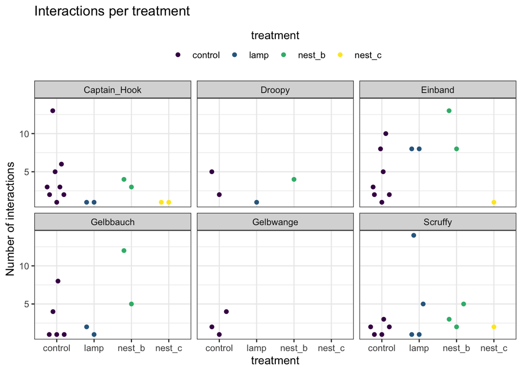

```r
interaction_count_tr<-interaction %>% dplyr::count(identity,treatment,exp_id, sort = TRUE)
interaction_count_cl<-interaction %>% dplyr::count(identity,closeness,exp_id, sort = TRUE)
#boxplot for interaction per treatment per indiviual
ggplot(interaction_count_tr, aes(x=treatment, y=n,colour=treatment))  +  #or distance_food
   geom_quasirandom()+theme_bw()+scale_color_viridis(discrete = T)+facet_wrap(. ~ identity)+theme(legend.position = 'top')+
  guides(color = guide_legend(title.position = 'top', title.hjust = .5, barwidth = unit(20, 'lines'), barheight = unit(.5, 'lines')))+ylab("Number of interactions") + labs(title="Interactions per treatment")
```

```r
#plot of interaction counts normalized over exp_id per individual per treatment
interaction_count_cl$identity<-as.factor(interaction_count_cl$identity)
levels(interaction_count_cl$exp_id)<-sort(c(levels(interaction_count_cl$exp_id),"5-1"))

for (x in levels(interaction_count_cl$exp_id)){
  for(y in levels(interaction_count_cl$identity)){
    if(sum(interaction$identity==y & interaction$exp_id==x)==0){
      print(paste(x,y))
      tmp<-interaction_count_cl[interaction_count_cl$identity==y,][1,]
      tmp[,3]<-x
      tmp[,4]<-0
      interaction_count_cl<-rbind(interaction_count_cl,tmp)
    }
  }
}
```

```
## [1] "5-1 Captain_Hook"
```

```
## [1] "5-1 Droopy"
## [1] "5-1 Einband"
## [1] "5-1 Gelbbauch"
## [1] "5-1 Gelbwange"
## [1] "5-1 Scruffy"
```

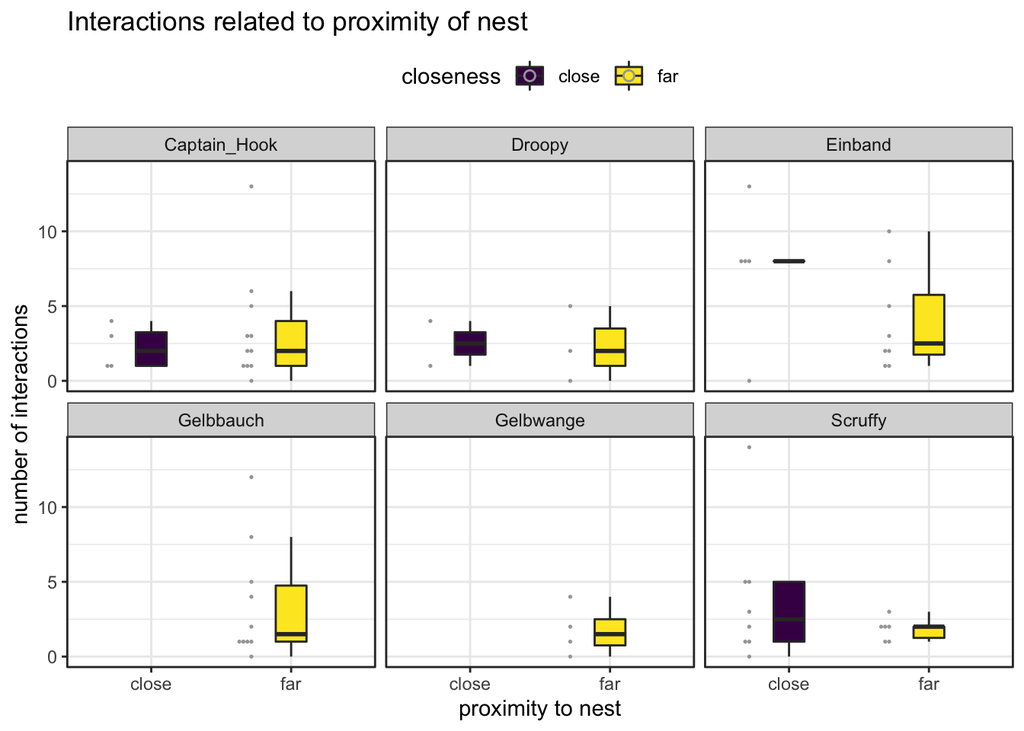

```r
#boxplot for interactions related to proximity of nest
ggplot(interaction_count_cl, aes(x=closeness, y=n,fill=closeness)) +
  ## add half-violin from {ggdist} package
  geom_boxplot(
    width = .22,
    ## remove outliers
    outlier.color = NA ## `outlier.shape = NA` works as well
  ) +
  ## add dot plots from {ggdist} package
  ggdist::stat_dots(
    ## orientation to the left
    side = "left",
    ## move geom to the left
    justification = 1.3,
    ## adjust grouping (binning) of observations
    binwidth = .25
  )+
  theme_bw()+scale_fill_viridis(discrete = TRUE)+facet_wrap(. ~ identity)+theme(legend.position = 'top')+guides(color = guide_colorbar(title.position = 'top', title.hjust = .5,
 barwidth = unit(20, 'lines'), barheight = unit(.5, 'lines')))+
  coord_cartesian(xlim = c(1, NA), clip = "off") +
  labs(title="Interactions related to proximity of nest") +
ylab("number of interactions") + xlab("proximity to nest")
```

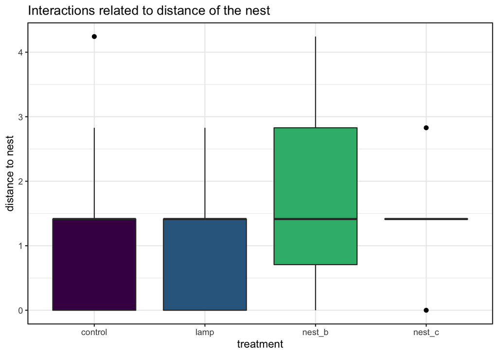

```r
#dist(rbind(tmp,nest_coord[,1]))
#boxplot for interactions, distances per treatment
ggplot(interaction, aes(x=treatment, y=distance_nest,fill=treatment)) + #or distance_food
  geom_boxplot(outlier.colour="black", outlier.shape=16,
             outlier.size=2, notch=FALSE,show.legend=F) +
  theme_bw()+scale_fill_viridis(discrete = T)+theme(legend.position = 'top')+
  guides(fill = guide_legend(title.position = 'top',override.aes=list(size=10), title.hjust = .5,
 barwidth = unit(20, 'lines'), barheight = unit(.5, 'lines')))+
  coord_cartesian(xlim = c(1, NA), clip = "off") +
  labs(title="Interactions related to distance of the nest") +
xlab("treatment") + ylab("distance to nest")
```

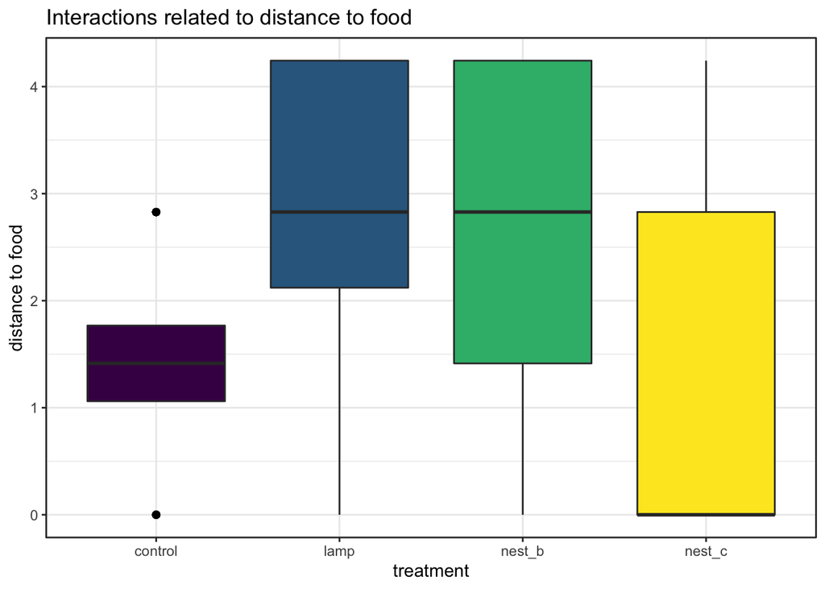

```r
#distance_food
ggplot(interaction, aes(x=treatment, y=distance_food,fill=treatment)) + #or distance_food
  geom_boxplot(outlier.colour="black", outlier.shape=16,
             outlier.size=2, notch=FALSE,show.legend=F) +
  theme_bw()+scale_fill_viridis(discrete = T)+theme(legend.position = 'top')+
  guides(fill = guide_legend(title.position = 'top',override.aes=list(size=10), title.hjust = .5,
 barwidth = unit(20, 'lines'), barheight = unit(.5, 'lines')))+
  coord_cartesian(xlim = c(1, NA), clip = "off") +
  labs(title="Interactions related to distance to food") +
xlab("treatment") + ylab("distance to food")
```

Creating heatmaps for interaction per treatment

[figure not shown]

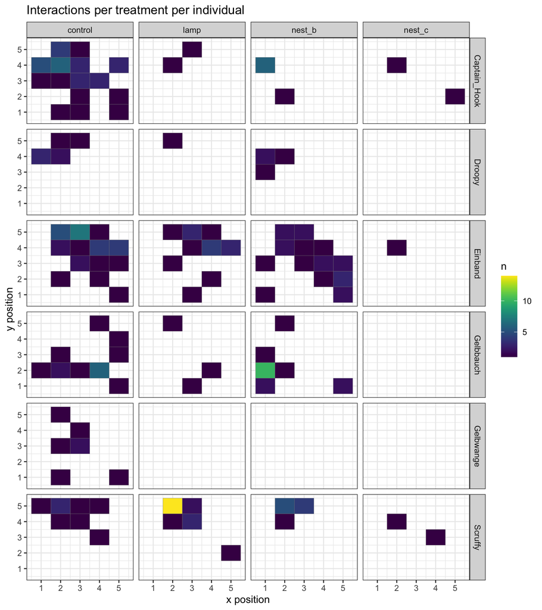

[figure not shown]

[figure not shown]

```r
#Interaction plot per treatment per individual
interaction_count<-interaction %>% dplyr::count(x_pos,y_pos,treatment,identity, sort = TRUE)
ggplot(interaction_count,aes(x=x_pos,y=y_pos,fill=n))+geom_tile( colour = "grey50")+scale_fill_viridis() + theme_bw()+facet_grid(identity~treatment)+
 labs(title="Interactions per treatment per individual") +
ylab("y position") + xlab("x position")
```

```r
ks.test(interaction$distance_food,"punif",0,5)
```

```
##
##  One-sample Kolmogorov-Smirnov test
##
## data:  interaction$distance_food
## D = 0.2527, p-value = 3.959e-12
## alternative hypothesis: two-sided
```